# Selective Diffusion

Oromia Sero and Jacob VanNattan

2026-05-28

# 1 Introduction

We study selective information diffusion in a population divided into two groups whose members cannot reliably distinguish one another. Each group holds information that benefits its members when shared internally and harms them when leaked to the other group. Institutional mechanisms for solving this problem, including cryptography, formal credentials, and hierarchical authority, are unavailable; agents must decide individually whether to share, on the basis of an imperfect signal of the recipient’s group. The strategic communication literature, beginning with (Crawford and Sobel 1982), studies how senders with private information transmit to receivers whose preferences diverge from their own. We follow a similar sender-receiver structure but make the divergence one of group membership rather than continuous policy, and make group identity itself the object of uncertainty.

To fix ideas, suppose an alien invasion has disabled Earth’s satellites, restricting humans and aliens alike to shortwave radio, with no cryptographic protocols established in advance. Both groups hold information they want to circulate internally, such as battle plans and resource locations, while denying it to the other. An agent initiating contact forms a noisy impression of the recipient’s identity from the channel but cannot verify it, and must decide whether to transmit. Analogues range from intra-group cooperation in segmented populations (Currarini et al. 2009) to the management of proprietary information by competing firms (Anton and Yao 2004).

We first derive closed-form thresholds characterizing when a rational agent transmits, as functions of the signal accuracy and the cost-to-benefit ratio of leakage. These partition agent beliefs into three regimes: silence, screening, and broadcast. We then simulate the population dynamics, drawing on the network diffusion literature (Jackson and Yariv 2007), to measure how much information diffuses within each group and how much leaks across. Section 2 formalizes the model and derives the decision rule, Section 3 presents the simulation, and Section 4 discusses applications and directions for future research.

# 2 Model

## 2.1 Setup

The population consists of $N$ agents, each belonging to one of two groups, $g \in \{ H,A\}$. Group membership is fixed throughout. We write $\varphi \in (0,1)$ for the population share of group $A$. Each agent $i$ holds a single piece of information indexed by $i$ and tagged with their group $g_{i}$. Pieces are objects that can be transmitted between agents and accumulated in inventories. Each agent also holds a prior $p_{i} \in (0,1)$ over the probability that a random partner shares their group.

At each time step, an active sender $i$ attempts to contact a partner $j$ drawn uniformly at random from the set of agents $i$ has not yet attempted. Before transmitting, the sender observes a signal $s \in \{ + , - \}$ of the recipient’s group identity. The signal is correct with probability $q \in (1/2,1\rbrack$:

$$\Pr(s = + \mid g_{j} = g_{i}) = q,\quad\quad\Pr(s = - \mid g_{j} = g_{i}) = 1 - q,$$

and symmetrically when $g_{j} \neq g_{i}$. The sender then decides whether to transmit. If transmission occurs, the recipient obtains the piece of information.

Payoffs are accrued at the level of the sender’s group. A successful in-group diffusion, in which $g_{j} = g_{i}$, contributes $+ R$ to group $g_{i}$’s welfare. An out-group diffusion, in which $g_{j} \neq g_{i}$, contributes $- F$. Rejection or non-transmission yields zero. We assume $R,F > 0$ and define the cost-to-benefit ratio $\rho = F/R$. Each group’s total utility is the sum of these contributions across all attempts initiated by its members. Agents are risk-neutral: each evaluates an encounter by its expected payoff, so an agent’s utility from a transmission decision is linear in $R$ and $F$. This linearity reduces the transmit decision to a single threshold in the posterior belief, derived in Section 2.3.

## 2.2 Assumptions

We make the following simplifying assumptions.

1. *Structural symmetry.* The two groups share the same signal accuracy $q$, the same payoff parameters $R$ and $F$, and the same decision rule.
2. *Heterogeneous static priors.* Agents are initialized with heterogeneous priors $p_{i}$ drawn from a distribution centered at the true population share. Priors do not update over the course of the simulation.
3. *Myopic optimization.* Agents maximize expected payoff one encounter at a time. They do not reason about how their decisions affect future information flow or future encounters.
4. *Receiving is costless.* Receiving information imposes no penalty on the recipient. Recipients always accept whatever is transmitted. The strategic content of the model lives entirely in the sender’s decision.
5. *No redundant requests.* A sender never attempts the same recipient twice.
6. *Unstructured contact pool.* Although accepted contacts form a network ex post, the underlying pool of potential partners is complete: every agent may, in principle, contact every other.

## 2.3 Sender’s decision

Sender $i$ holds prior $p_{i}$ over the probability that a random partner is in-group and observes a signal $s \in \{ + , - \}$. The Bayesian posteriors are

$${\widehat{p}}_{+} = \frac{q\, p_{i}}{q\, p_{i} + (1 - q)(1 - p_{i})},\quad\quad{\widehat{p}}_{-} = \frac{(1 - q)\, p_{i}}{(1 - q)\, p_{i} + q\,(1 - p_{i})}.$$

The sender transmits if and only if expected payoff is positive, $\widehat{p} \cdot R - (1 - \widehat{p}) \cdot F > 0$, which simplifies to

$$\widehat{p} > \frac{\rho}{1 + \rho}.$$

This produces three regimes in the sender’s prior $p_{i}$:

- $p_{i} < p^{\text{low}} \equiv \frac{(1 - q)\,\rho}{q + (1 - q)\,\rho}$: *silence*, the sender does not transmit.
- $p^{\text{low}} < p_{i} < p^{\text{high}} \equiv \frac{q\,\rho}{(1 - q) + q\,\rho}$: *screening*, the sender transmits only on a positive signal.
- $p_{i} > p^{\text{high}}$: *broadcast*, the sender transmits regardless of signal.

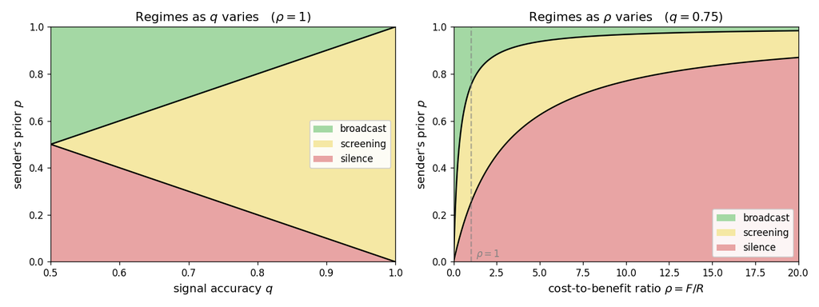

At $\rho = 1$ and $q = 0.75$, for example, the screening interval is $(0.25,0.75)$. As $\rho$ approaches zero, both thresholds collapse to zero and all agents broadcast. As $\rho$ grows large, both thresholds approach one and all agents fall silent. Increasing $q$ widens the screening regime by lowering $p^{\text{low}}$ and raising $p^{\text{high}}$. Figure 1 visualizes both comparative statics.

# 3 Agent-Based Network Model

## 3.1 Set up

Using Agent Based Modeling, we model in a directed network $G_{t} = (V,E_{t})$, where $V$ is the set of agents, $E_{t}$ is the set of directed edges at time $t$, and $|V| = N$. Each agent $i \in V$ is assigned a type $T_{i} \in \{ H,A\}$, where $H$ denotes human and $A$ denotes alien. Each agent is initialized with unique information, an initial expected value

$$U(0) = 0,$$

and an individual prior $p_{i}$, as in Section 2.

At each timestep $t$, a subset of agents becomes active. Each active sender agent $i$ randomly selects a receiver $j$, excluding agents whom $i$ has already contacted successfully or rejected. The sender observes a noisy signal $s_{ij}$ about the receiver’s type. The signal is correct with probability $q$, so that

$$\Pr(s_{ij} = T_{j}) = q.$$

The sender applies the transmit rule of Section 2.3.

If accepted, a directed edge from $i$ to $j$ is added to the network. The sender transmits its unique information to the receiver. If $i$ and $j$ are both human, the interaction is counted as successful diffusion, and the payoff increases by $1$. If $i$ is human and $j$ is alien, the interaction is counted as incorrect diffusion, and the payoff decreases by $1$. If the link is rejected, no information is transmitted, and there is no payoff. By structural symmetry (Assumption 1), the alien group behaves identically with the types reversed, so we state the update from the human perspective without loss of generality.

The utility update is therefore

$$U_{i}(t + 1) = \left\{ \begin{matrix}
U_{i}(t) + 1, & \text{if }T_{i} = H,\ T_{j} = H\text{ and the link is accepted}, \\
U_{i}(t) - 1, & \text{if }T_{i} = H,\ T_{j} = A\text{ and the link is accepted}, \\
U_{i}(t), & \text{otherwise}.
\end{matrix} \right.\$$

## 3.2 Results

The simulation was initialized as a directed network of 100 agents, with agents randomly assigned as human or alien in equal proportions. Each agent was given a noisy prior centered on the true population share, and the model was run for 200 timesteps while varying signal accuracy.

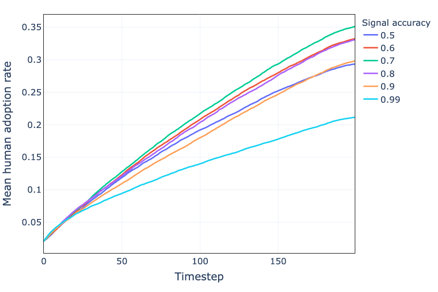

**Figure 2:**Mean human information adoption over time by signal accuracy. Higher signal accuracy can reduce diffusion because agents more reliably identify risky out-group receivers and reject more potential links. Lower signal accuracy increases mistaken human-to-alien sharing, but aliens can also mediate further diffusion by carrying and retransmitting human-origin information.

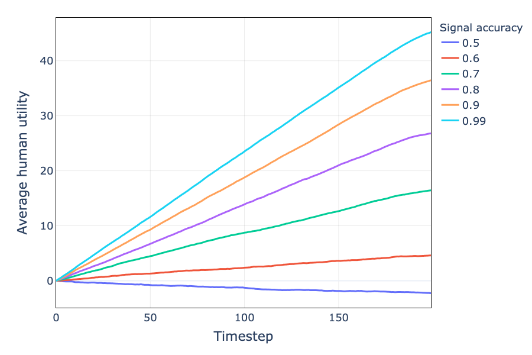

**Figure 3:**Average human utility over time by signal accuracy. Higher signal accuracy increases human utility by improving successful human-to-human diffusion and reducing mistaken sharing with aliens.

Additionally, setting the incorrect-diffusion payoff to zero increases both human adoption and the number of accepted links (see Figure 4). The result shows that reducing the cost of mistaken sharing promotes diffusion by weakening agents’ incentives to reject risky contacts, allowing information to diffuse more widely through both human-human and alien-mediated paths.

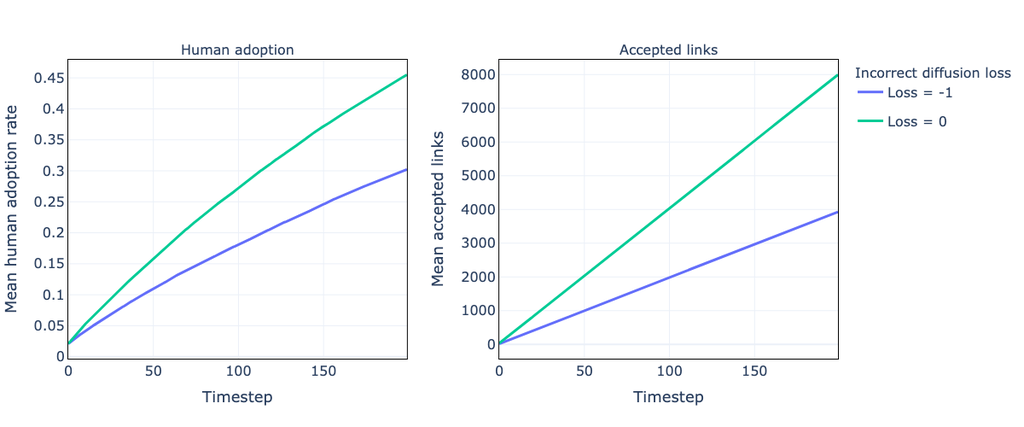

**Figure 4:** Human information adoption and accepted links by incorrect-diffusion loss. Left panel show the mean human information adoption rate, and the right panel reports the mean number of accepted directed links. When incorrect diffusion carries no loss, agents form more links and human-origin information spreads more widely.

# 4 Discussion

## 4.1 Applications

The model speaks to several settings where selective diffusion under noisy identity is at stake. The most direct is the protection of proprietary information by firms. An employee deciding whether to discuss firm matters with an outside contact faces exactly our trade-off: a noisy read on whether the listener is a colleague, a competitor, or neither. Patent and trade secret law (Anton and Yao 2004) reduces the effective $\rho$ by providing recourse against appropriation; without it, firms would restrict information far more aggressively than is efficient, suppressing the within-industry spillovers that drive innovation. The same logic governs whistleblowing and source protection, where the threshold characterization explains why sources transmit only given strong prior signals, through trusted intermediaries or secure tools, and otherwise stay silent. It also rationalizes compartmentalized secrecy in intelligence and military settings, where classification and need-to-know rules substitute institutionally for the screening individual agents cannot perform themselves.

Artificial intelligence offers a case in which the comparative statics describe a moving target, since AI shifts $q$ in opposite directions depending on which side of the channel it sits. Voice authentication, writing-style biometrics, and anti-phishing classifiers raise effective signal accuracy, widening the screening regime and making selective diffusion feasible where it otherwise would not be. Generative impersonation, including voice cloning, machine-written phishing, and deepfaked credentials, lowers $q$ and pushes interactions toward silence. As both capabilities advance together, the $\rho$-side institutions matter most precisely when $q$-side verification becomes unreliable.

## 4.2 Future directions

Several extensions are natural follow ups to this initial study. Allowing priors to update through experience would let trust evolve endogenously. Relaxing structural symmetry, in $q$, payoffs, or population shares, would let us study minority/majority asymmetries. Embedding the model in a network with nontrivial topology would let us ask whether structure amplifies or contains leakage. Permitting strategic content, including fabricated messages, would introduce disinformation as a third action. Finally, forward-looking agents who account for downstream diffusion may arrive at different thresholds than the myopic ones derived here.

## References

Anton, James J., and Dennis A. Yao. 2004. “Little Patents and Big Secrets: Managing Intellectual Property.” *RAND Journal of Economics* 35 (1): 1–22.

Crawford, Vincent P., and Joel Sobel. 1982. “Strategic Information Transmission.” *Econometrica* 50 (6): 1431–51.

Currarini, Sergio, Matthew O. Jackson, and Paolo Pin. 2009. “An Economic Model of Friendship: Homophily, Minorities, and Segregation.” *Econometrica* 77 (4): 1003–45.

Jackson, Matthew O., and Leeat Yariv. 2007. “Diffusion of Behavior and Equilibrium Properties in Network Games.” *American Economic Review* 97 (2): 92–98.